# Lathyrus ms2: selection on reaction norms for flowering time

### Negative binomial distribution with zero-inflation

```r
bivar2.all.brm.zinb<-brm(bf_FFD+bf_fitness_shoot,
                       family = c(gaussian,zero_inflated_negbinomial),
                       data = datadef,warmup = 1000,iter = 2000,chains=4,thin=2,
                       inits = "random",seed = 12345,cores = my.cores,
                       control = list(adapt_delta = 0.99))
```

```r
summary(bivar2.all.brm.zinb)
```

```
 Family: MV(gaussian, zero_inflated_negbinomial)
  Links: mu = identity; sigma = identity
         mu = log; shape = identity; zi = identity
Formula: FFD ~ cmean_4 + (cmean_4 | ID1 | id) + (1 | year)
         round(mean_fitness_fl) ~ cn_shoot_vol_mean_sqrt + (1 | ID1 | id)
   Data: datadef (Number of observations: 2432)
Samples: 4 chains, each with iter = 2000; warmup = 1000; thin = 2;
         total post-warmup samples = 2000

Group-Level Effects:
~id (Number of levels: 791)
                                                Estimate Est.Error l-95% CI
sd(FFD_Intercept)                                   1.67      0.15     1.37
sd(FFD_cmean_4)                                     0.81      0.13     0.56
sd(roundmeanfitnessfl_Intercept)                    1.24      0.05     1.14
cor(FFD_Intercept,FFD_cmean_4)                      0.64      0.13     0.35
cor(FFD_Intercept,roundmeanfitnessfl_Intercept)    -0.44      0.07    -0.58
cor(FFD_cmean_4,roundmeanfitnessfl_Intercept)       0.15      0.13    -0.11
                                                u-95% CI Rhat Bulk_ESS
sd(FFD_Intercept)                                   1.97 1.00     1207
sd(FFD_cmean_4)                                     1.09 1.00      765
sd(roundmeanfitnessfl_Intercept)                    1.34 1.00     1333
cor(FFD_Intercept,FFD_cmean_4)                      0.87 1.01      306
cor(FFD_Intercept,roundmeanfitnessfl_Intercept)    -0.30 1.01      542
cor(FFD_cmean_4,roundmeanfitnessfl_Intercept)       0.41 1.00      591
                                                Tail_ESS
sd(FFD_Intercept)                                   1693
sd(FFD_cmean_4)                                     1594
sd(roundmeanfitnessfl_Intercept)                    1668
cor(FFD_Intercept,FFD_cmean_4)                       822
cor(FFD_Intercept,roundmeanfitnessfl_Intercept)     1101
cor(FFD_cmean_4,roundmeanfitnessfl_Intercept)       1267

~year (Number of levels: 22)
                  Estimate Est.Error l-95% CI u-95% CI Rhat Bulk_ESS Tail_ESS
sd(FFD_Intercept)     5.20      0.86     3.78     7.16 1.00     1054     1362

Population-Level Effects:
                                          Estimate Est.Error l-95% CI
FFD_Intercept                                58.53      1.12    56.23
roundmeanfitnessfl_Intercept                  0.79      0.05     0.69
FFD_cmean_4                                  -2.37      0.86    -4.19
roundmeanfitnessfl_cn_shoot_vol_mean_sqrt     0.04      0.00     0.03
                                          u-95% CI Rhat Bulk_ESS Tail_ESS
FFD_Intercept                                60.74 1.00      829     1273
roundmeanfitnessfl_Intercept                  0.90 1.00     1741     1615
FFD_cmean_4                                  -0.70 1.00      925     1326
roundmeanfitnessfl_cn_shoot_vol_mean_sqrt     0.05 1.00     1814     1858

Family Specific Parameters:
                         Estimate Est.Error l-95% CI u-95% CI Rhat Bulk_ESS
sigma_FFD                    4.34      0.07     4.21     4.49 1.00     1237
shape_roundmeanfitnessfl   661.16    186.43   362.87  1098.48 1.00     1444
zi_roundmeanfitnessfl        0.00      0.00     0.00     0.00 1.00     1649
                         Tail_ESS
sigma_FFD                    1630
shape_roundmeanfitnessfl     1430
zi_roundmeanfitnessfl        1542

Samples were drawn using sampling(NUTS). For each parameter, Bulk_ESS
and Tail_ESS are effective sample size measures, and Rhat is the potential
scale reduction factor on split chains (at convergence, Rhat = 1).
```

### Model evaluation: Compare models

Looking only at negative binomial models by now, as Poisson model gave warnings.

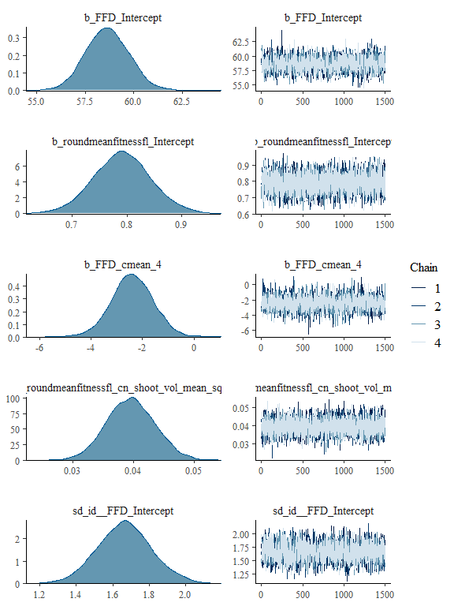

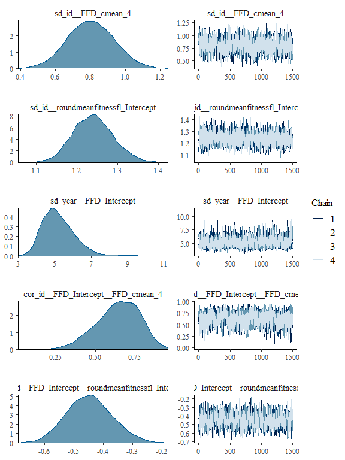

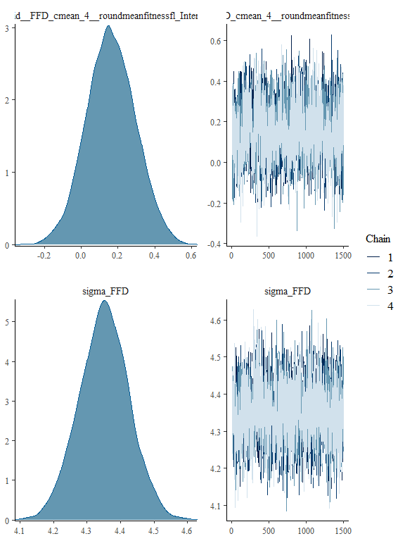

```r
#plot(bivar2.all.brm.pois)
plot(bivar2.all.brm.nb)
```

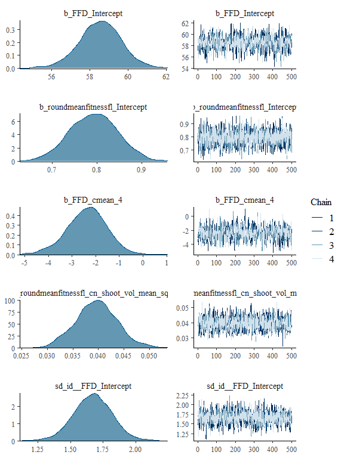

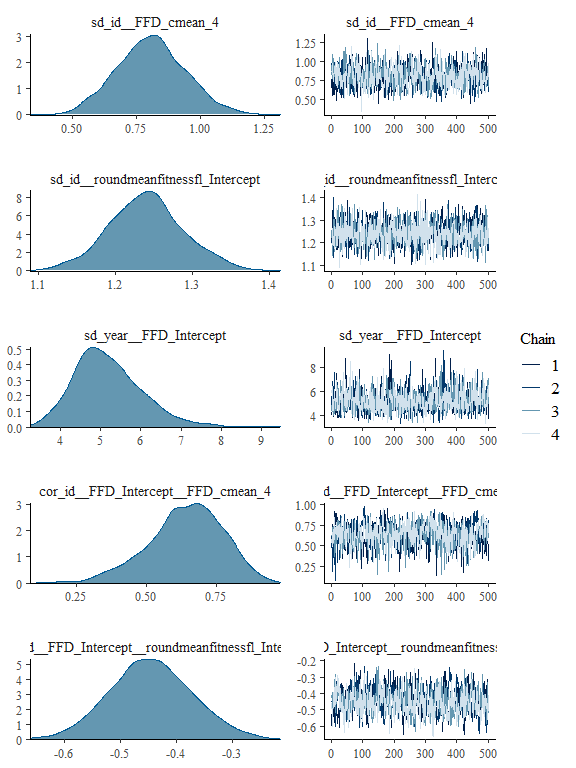

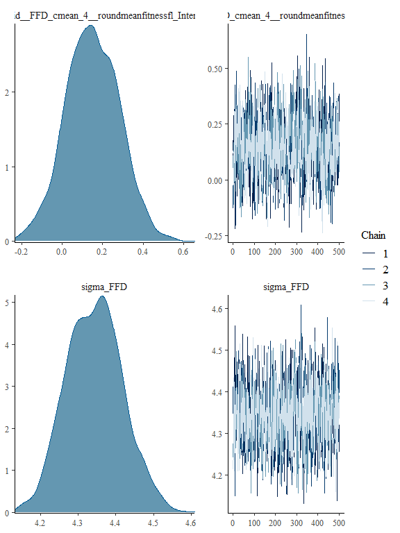

```r
plot(bivar2.all.brm.zinb)
```

Rhat

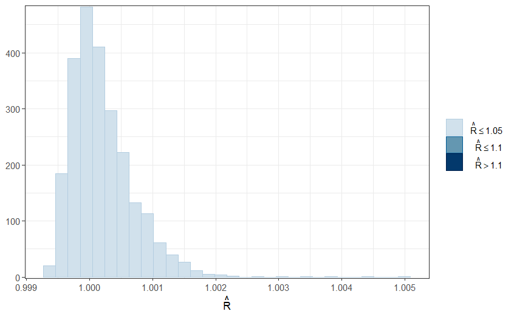

```r
#mcmc_rhat_hist(rhat(bivar2.all.brm.pois))+theme_bw()
mcmc_rhat_hist(rhat(bivar2.all.brm.nb))+theme_bw()
```

```r
mcmc_rhat_hist(rhat(bivar2.all.brm.zinb))+theme_bw()
```

[output not shown]

Effective sample size:

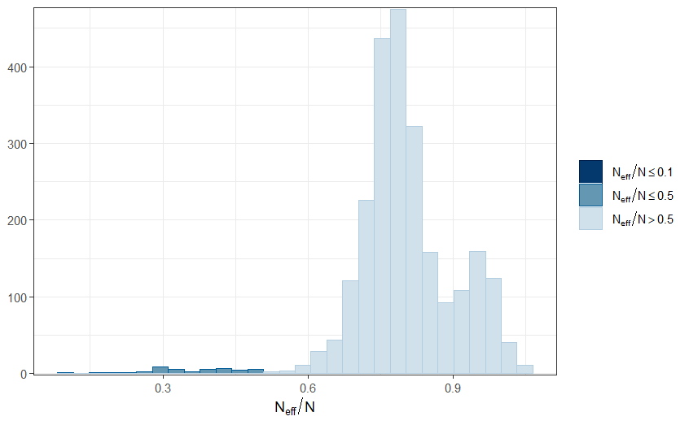

```r
#mcmc_neff_hist(neff_ratio(bivar2.all.brm.pois))+theme_bw()
mcmc_neff_hist(neff_ratio(bivar2.all.brm.nb))+theme_bw()
```

```r
mcmc_neff_hist(neff_ratio(bivar2.all.brm.zinb))+theme_bw()
```

[output not shown]

Posterior predictive checks:

```r
y3_fitness<-round(subset(datadef,!is.na(FFD)&
                           !is.na(cn_shoot_vol_mean_sqrt))$mean_fitness_fl)
y3_FFD<-subset(datadef,!is.na(FFD)&
                           !is.na(cn_shoot_vol_mean_sqrt))$FFD
# vectors of outcome values
#yrep3_fitness_pois<-posterior_predict(bivar2.all.brm.pois,
#                                      draws = 500,resp="roundmeanfitnessfl")
#yrep3_FFD_pois<-posterior_predict(bivar2.all.brm.pois,
#                                  draws = 500,resp="FFD")
yrep3_fitness_nb<-posterior_predict(bivar2.all.brm.nb,
                                    draws = 500,resp="roundmeanfitnessfl")
```

Each row of the matrix is a draw from the posterior predictive distribution, i.e. a vector with one element for each of the data points in y.

Comparison of the distribution of y and the distributions of the simulated datasets in the yrep matrix

```r
#ppc_dens_overlay(y3_fitness, yrep3_fitness_pois[1:500,])
#ppc_dens_overlay(y3_fitness, yrep3_fitness_pois[1:500,])+xlim(0, 10)
ppc_dens_overlay(y3_fitness, yrep3_fitness_nb[1:500,])
```

[output not shown]

Separate histograms of y and some of the yrep datasets

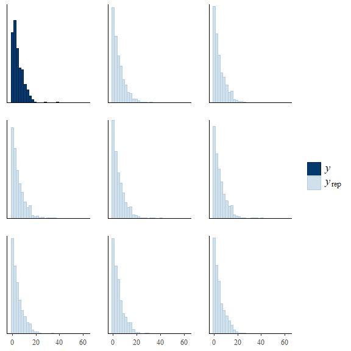

```r
#ppc_hist(y3_fitness, yrep3_fitness_pois[1:8, ])
#ppc_hist(y3_fitness, yrep3_fitness_pois[1:8, ])+
#  coord_cartesian(xlim = c(-1, 20))
ppc_hist(y3_fitness, yrep3_fitness_nb[1:8, ])
```

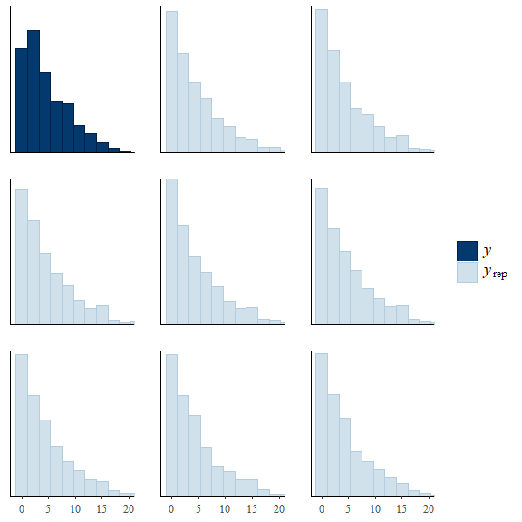

```r
ppc_hist(y3_fitness, yrep3_fitness_nb[1:8, ])+
  coord_cartesian(xlim = c(-1, 20))
```

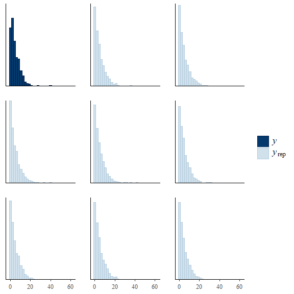

```r
ppc_hist(y3_fitness, yrep3_fitness_zinb[1:8, ])
```